# RNA-seq analysis in R

Gene Set Testing for RNA-seq - Solutions

Stephane Ballereau, Mark Dunning, Oscar Rueda, Ashley Sawle

Last modified: 17 Jul 2019

## Challenge 1

> Another common way to rank the genes is to order by pvalue, but also, sorting so that upregulated genes are at start and downregulated at the other - you can do this combining the sign of the fold change and the pvalue. 1. Rank the genes by statisical significance - you will need to create a new ranking value using `-log10({p value}) * sign({Fold Change})` 2. Load the “C2” pathways from the the `data/mouse_c2_v5.RData` file 3. Run `fgsea` using the new ranked genes and the C2 pathways 4. Run `fgsea` using the new ranked genes and the H pathways. How do these results differ from the ones we got when ranking by the fold change alone?

```r
ranks <- -log10(gseaDat$pvalue) * sign(gseaDat$logFC)
names(ranks) <- gseaDat$Entrez

load("../Robjects/mouse_c2_v5.RData")
pathwaysC2 <- Mm.c2

fgseaResC2 <- fgsea(pathwaysC2, ranks, minSize=15, maxSize = 500, nperm=1000)
head(fgseaResC2[order(padj, -abs(NES)), ], n=10)
```

```
##                                                                    pathway
##  1:                                          REACTOME_INFLUENZA_LIFE_CYCLE
##  2: REACTOME_NONSENSE_MEDIATED_DECAY_ENHANCED_BY_THE_EXON_JUNCTION_COMPLEX
##  3:                       REACTOME_3_UTR_MEDIATED_TRANSLATIONAL_REGULATION
##  4:                                      REACTOME_PEPTIDE_CHAIN_ELONGATION
##  5:             REACTOME_INFLUENZA_VIRAL_RNA_TRANSCRIPTION_AND_REPLICATION
##  6:                                                          KEGG_RIBOSOME
##  7:                                             REACTOME_METABOLISM_OF_RNA
##  8:                                            REACTOME_METABOLISM_OF_MRNA
##  9:   REACTOME_SRP_DEPENDENT_COTRANSLATIONAL_PROTEIN_TARGETING_TO_MEMBRANE
## 10:                                                   REACTOME_TRANSLATION
##            pval       padj         ES       NES nMoreExtreme size
##  1: 0.002267574 0.05313355 -0.8585177 -2.673167            0  128
##  2: 0.002331002 0.05313355 -0.8873458 -2.649677            0  100
##  3: 0.002331002 0.05313355 -0.8855713 -2.644379            0  100
```

[output cut: 18 more lines]

```r
fgseaResH <- fgsea(pathwaysH, ranks, minSize=15, maxSize = 500, nperm=1000)
head(fgseaResH[order(padj, -abs(NES)), ], n=20)
```

```
##                                 pathway        pval        padj         ES
##  1:             HALLMARK_MYC_TARGETS_V1 0.002232143 0.008585165 -0.6826742
##  2:  HALLMARK_OXIDATIVE_PHOSPHORYLATION 0.001834862 0.008585165  0.6475885
##  3:         HALLMARK_TGF_BETA_SIGNALING 0.002100840 0.008585165 -0.7419824
##  4:             HALLMARK_MYC_TARGETS_V2 0.002109705 0.008585165 -0.7011704
##  5:    HALLMARK_CHOLESTEROL_HOMEOSTASIS 0.001964637 0.008585165  0.7008853
##  6:                HALLMARK_E2F_TARGETS 0.002232143 0.008585165 -0.5619850
##  7:               HALLMARK_ADIPOGENESIS 0.001824818 0.008585165  0.5730449
##  8:      HALLMARK_FATTY_ACID_METABOLISM 0.001872659 0.008585165  0.5762348
##  9:           HALLMARK_MTORC1_SIGNALING 0.001818182 0.008585165  0.5499793
## 10: HALLMARK_WNT_BETA_CATENIN_SIGNALING 0.002178649 0.008585165 -0.6575068
## 11:             HALLMARK_G2M_CHECKPOINT 0.002232143 0.008585165 -0.5058712
## 12:    HALLMARK_ESTROGEN_RESPONSE_EARLY 0.002197802 0.008585165 -0.4818514
## 13:        HALLMARK_ALLOGRAFT_REJECTION 0.002188184 0.008585165 -0.4604850
## 14:                 HALLMARK_PEROXISOME 0.003824092 0.013657471  0.6087801
```

[output cut: 48 more lines]

## Challenge 2

> 1. Create a gene list for genes that are up-regulated by at least 4x (logFC>2) in lactating mice
> 2. Run a `goseq` analysis on this gene list
> 3. Plot the results
> 4. How is this result different to the previous GO analysis?

Look at genes that are up regulated by at least 4x (logFC>2) in lactating mices

```r
isSigGeneUp <- shrinkLvV$FDR < 0.01 &
    !is.na(shrinkLvV$FDR) &
    shrinkLvV$logFC > 2

genesUp <- as.integer(isSigGeneUp)
names(genesUp) <- shrinkLvV$GeneID

pwf <- nullp(genesUp, "mm10", "ensGene", bias.data = shrinkLvV$medianTxLength)
```

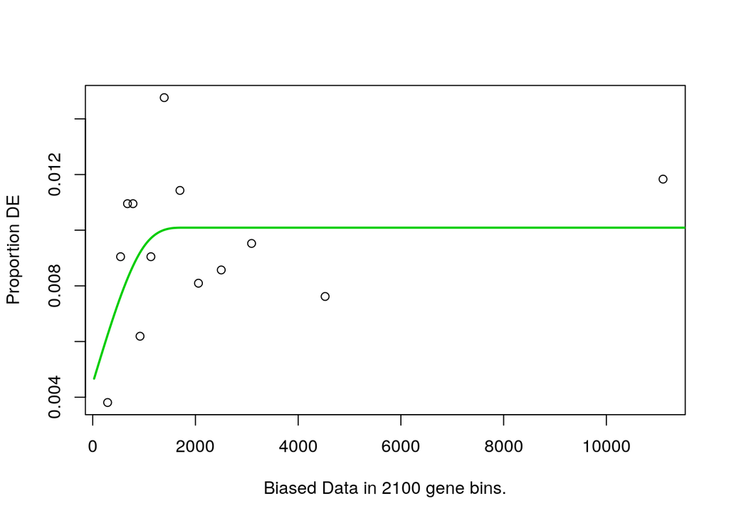

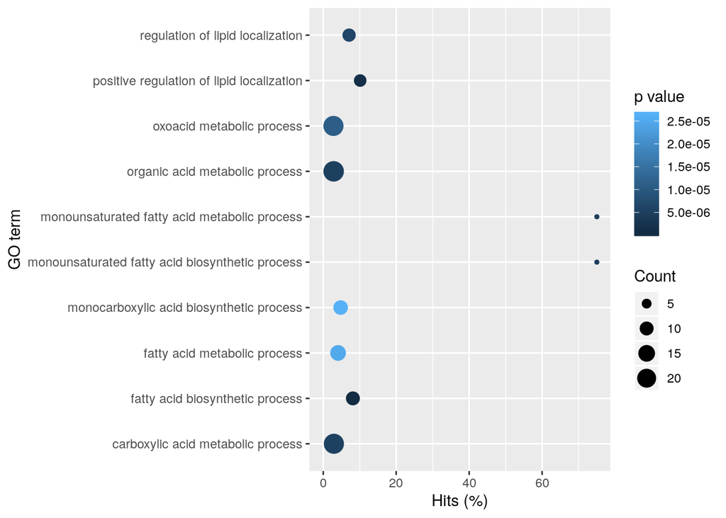

```r
goResultsUp <- goseq(pwf, "mm10","ensGene", test.cats=c("GO:BP"))

goResultsUp %>%
    top_n(10, wt=-over_represented_pvalue) %>%
    mutate(hitsPerc=numDEInCat*100/numInCat) %>%
    ggplot(aes(x=hitsPerc,
               y=term,
               colour=over_represented_pvalue,
               size=numDEInCat)) +
        geom_point() +
        expand_limits(x=0) +
        labs(x="Hits (%)", y="GO term", colour="p value", size="Count")
```

## Challenge 3

> 1. Use `pathview` to export a figure for “mmu04060”, but this time only use genes that are statistically significant at FDR < 0.01

```r
sigGenes <- shrinkLvV$FDR < 0.01 & !is.na(shrinkLvV$FDR)

logFC <- annotLvV$logFC[sigGenes]
names(logFC) <- annotLvV$Entrez[sigGenes]

pathview(gene.data = logFC,
         pathway.id = "mmu04060",
         species = "mmu",
         limit = list(gene=5, cpd=1))
```

```
## Info: Downloading xml files for mmu04060, 1/1 pathways..
```

```
## Info: Downloading png files for mmu04060, 1/1 pathways..
```

```
## Info: Working in directory /home/participant/Documents/CRUK_CI_RNAseq_course/Course_Materials/solutions
```

```
## Info: Writing image file mmu04060.pathview.png
```

mmu04060.pathview.png:

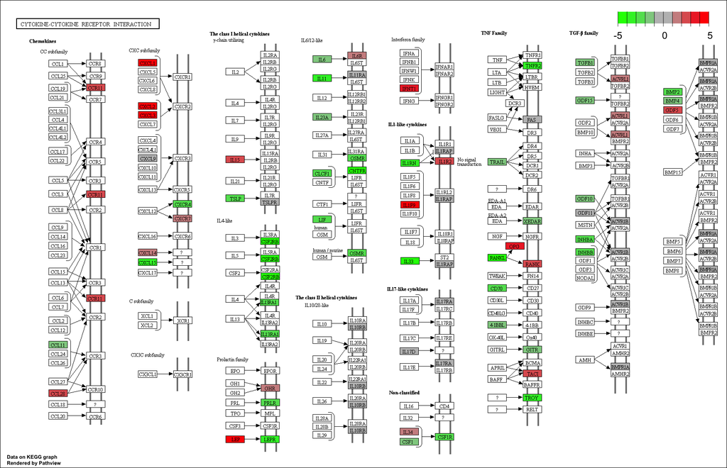

mmu04060 -Cytokine-cytokine receptor interaction